# Ollama_blog

## How to Run LLMs Locally with Ollama

This document explains setting up Ollama to utilize LLMs on localy. Local deployment ensures data privacy, cost efficiency, and customization.

### Ollama Installation

Download the Ollama installer for Windows from https://ollama.com/download/windows. Execute the downloaded file to initiate the installation process.

By default, Ollama is installed to `C:\Users\<USERNAME>\AppData\Local\Programs\Ollama`, where `<USERNAME>` represents the current user's account name.

For installation in a custom directory, adhere to the following procedure:

1. In Command Prompt, navigate to the directory containing the Ollama setup file using the command `cd /d <OLLAMA SETUP FILE PATH>`. For example: `cd /d "C:\Users\<USERNAME>\Downloads\"`.
2. Execute `ollamasetup.exe /DIR="d:/ollama"` to install Ollama in the designated `D:\ollama` directory.

### Download Ollama Models

To download models from Ollama, execute the following command in Command Prompt: `ollama pull`. For example, `ollama pull deepseek-r1`.

By default, model files are downloaded to `C:\Users\<USERNAME>\.ollama\models`. To specify a custom download directory, configure the environment variable `OLLAMA_MODELS` to your preferred folder. Follow these steps:

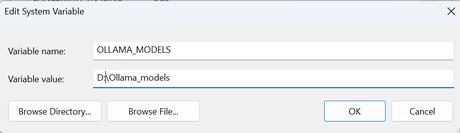

After configuring the variable, executing `ollama pull` should download models to the designated custom folder. If the models do not download to the new location, restart Ollama, then close and reopen Command Prompt before retrying.

With the models successfully downloaded, the following sections will explore the various methods for utilizing local large language models (LLMs) obtained through Ollama.

### Install the required packages using

```python
!pip install ollama langchain-ollama requests io PIL matplotlib
```

### Methods for Utilizing Ollama

- Using the `Ollama` Python package
- Leveraging the `LangChain` package
- Making API calls with the `requests` library

### text model

#### Text

```python
%%time
import ollama

# Use Ollama to clean and structure the OCR output
response = ollama.chat(
    model="llama3.2-vision",
    messages=[
       {
            "role": "system",
            "content": "You are an AI assistant, answering user questions."
        },
        {
            "role": "user",
            "content": "Who won the 2011 cricket worldcup?"
        }
        ],
)

# Extract cleaned text
cleaned_text = response['message']['content'].strip()
print(cleaned_text)
```

```
India won the 2011 ICC Cricket World Cup, defeating Sri Lanka in the final on April 2, 2011, at the Wankhede Stadium in Mumbai, India. It was a thrilling match that went down to the wire, with India eventually winning by six wickets. This was India's second World Cup title, after their first win in …
CPU times: total: 0 ns
Wall time: 19.3 s
```

#### Image

```python
%%time
import matplotlib.pyplot as plt
from PIL import Image
from io import BytesIO
import requests
import ollama

# Download the image from a URL
url = "https://static.remove.bg/sample-gallery/graphics/bird-thumbnail.jpg"
response = requests.get(url)
if response.status_code == 200:
    image = Image.open(BytesIO(response.content))
    plt.imshow(image)
    plt.axis('off')
    plt.show()
else:
    print("Failed to download image. Status code:", response.status_code)

# Convert the image to bytes
image_bytes = BytesIO()
image.save(image_bytes, format=image.format)
image_bytes = image_bytes.getvalue()
print("Image converted to bytes successfully!")

# Use Ollama to pass the image to the model
response = ollama.chat(
    model="llama3.2-vision",
    messages=[{
      "role": "user",
      "content": "Describe the Image",
      "images": [image_bytes]
    }],
)
cleaned_text = response['message']['content'].strip()
print(cleaned_text)
```

[output not shown]

```
Image converted to bytes successfully!
The image depicts a vibrant, stylized hummingbird with a unique color scheme and design.

*   **Hummingbird:**
    *   The hummingbird is positioned in the center of the image.
    *   It has a long, curved beak that extends from its head to its chest.
    *   Its body is shaped like an elongated teardrop, with the pointed end facing downwards.
    *   The bird's wings are spread out to the sides, and they appear to be made up of many thin, colorful feathers.
    *   The hummingbird's tail feathers are long and slender, and they extend beyond the edges of the image.
*   **Color Scheme:**
    *   The hummingbird's body is a gradient of colors, ranging from pink at the top to purple towards the bottom.
    *   Its wings and tail feathers are made up of many different colors, including blue, green, yellow, orange, and red.
    *   The background of the image is a light gray color.
*   **Design Elements:**
    *   The hummingbird's body is surrounded by a series of curved lines that resemble the shape of a flower or a leaf.
    *   There are also some small, colorful shapes scattered throughout the image, which appear to be made up of tiny triangles and circles.

Overall, the image features a stylized hummingbird with a unique color scheme and design elements. The use of bright colors and geometric shapes gives the image a playful and modern feel.
CPU times: total: 156 ms
Wall time: 1min 12s
```

### Text

```python
from langchain_ollama import ChatOllama
from langchain_core.prompts import ChatPromptTemplate

# Initialize the Ollama language model
llm = ChatOllama(
    model="llama3.2:1b-instruct-fp16",
    temperature=0,
    num_predict=1024  # maximum number of tokens to generate
)

# Method 1 - Direct invocation of the model
llm.invoke("What is electroencephalography?")

# Method 2 - Using a prompt template and chain
template = """{question}"""
prompt = ChatPromptTemplate.from_template(template)
chain = prompt | llm
Ollama_gen_text = chain.invoke({"question": "What is electroencephalography?"})

# Print the generated response
print(Ollama_gen_text.content)
```

```
Electroencephalography (EEG) is a non-invasive medical test that measures the electrical activity of the brain. It's a technique used to record and analyze the brain's electrical signals, which are generated by the neurons in the brain.

During an EEG test, electrodes are placed on the scalp to capture the electrical impulses produced by the brain's neural activity. These electrodes are usually small, flat discs or pads that are attached to the skin using a conductive gel or adhesive.

The EEG signal is typically measured in millivolts (mV) and can be recorded over a wide range of frequencies, from low-frequency ripples (0-30 Hz) to high-frequency oscillations (100-500 Hz). The signal is then analyzed using specialized software to identify patterns, rhythms, and other characterist…

EEG is commonly used in various fields, including:

1. Neurology: To diagnose and monitor conditions such as epilepsy, seizures, and brain injuries.
2. Psychiatry: To assess cognitive function, mood, and emotional states in patients with psychiatric disorders.
3. Sleep medicine: To study sleep patterns and identify potential sleep disorders.
4. Neurosurgery: To evaluate the electrical activity of the brain during surgical procedures.
5. Research: To investigate the neural basis of various phenomena, such as perception, attention, and memory.

EEG is a valuable tool for understanding the brain's function and behavior, and it has many applications in both clinical and research settings.
```

### Image

```python
%%time
from langchain_ollama import OllamaLLM
from langchain_core.prompts import ChatPromptTemplate
import matplotlib.pyplot as plt
from PIL import Image
from io import BytesIO
import base64
import requests

# Initialize the Ollama vision model
image_llm = OllamaLLM(
    model="llava:7b",
    temperature=0,
    num_predict=1024  # maximum number of tokens to generate
)

# Download the image from a URL
image_url = "https://static.remove.bg/sample-gallery/graphics/bird-thumbnail.jpg"
response = requests.get(image_url)

# Convert the image to Base64 and prepare for display
base64_image = base64.b64encode(response.content).decode('utf-8')
print("Image converted to base64 successfully!")
image_data = base64.b64decode(base64_image)
image = Image.open(BytesIO(image_data))

# Display the image using matplotlib
plt.imshow(image)
plt.axis('off')  # Hide axes for a cleaner display
plt.show()

# Use the model to describe the image
llm_with_image_context = image_llm.bind(images=[base64_image])
llm_with_image_context.invoke("Describe the image")
```

[output not shown]

[output not shown]

```
Image converted to base64 successfully!
```

```
CPU times: total: 469 ms
Wall time: 2.19 s
```

### Text

```python
import requests
import json

# Define the API endpoint and payload
url = 'http://localhost:11434/api/generate'
payload = {
    'model': 'llama3.2:1b',
    'prompt': 'What is the meaning of life?',
    'stream': False
}

# Send the API request
response = requests.post(url, json=payload)

# Handle the response
if response.status_code == 200:
    print(response.json()['response'])
else:
    print(f"Error: {response.status_code} - {response.text}")
```

```
The question of the meaning of life is a profound and complex one that has been debated by philosophers, theologians, scientists, and everyday people for centuries. There is no one definitive answer, and different cultures and individuals may have different perspectives on this topic.

Some possible answers to the question of the meaning of life include:

1. Finding purpose and fulfillment through personal growth and self-actualization.
2. Creating something of value and leaving a lasting impact on the world.
3. Cultivating meaningful relationships and connections with others.
4. Pursuing knowledge, understanding, and discovery.
5. Overcoming adversity and finding strength in the face of challenges.

Ultimately, the meaning of life is a deeply personal and subjective question that each individual must answer for themselves. It may involve exploring one's values, passions, and talents, as well as reflecting on their experiences, goals, and aspirations.

Some famous philosophers have offered their insights on the matter:

- Aristotle believed that the meaning of life was to achieve eudaimonia, a state of happiness and fulfillment that comes from living a virtuous life.
- Jean-Paul Sartre argued that human beings have complete freedom to choose their own path in life, but are also responsible for creating their own meaning.
- Martin Luther King Jr. believed that the meaning of life was to find freedom and justice for all people.

In terms of science, some possible answers to the question of the meaning of life include:

- The purpose of human existence may be to survive and thrive in a challenging environment.
- Life may be driven by the search for novelty and the desire to experience new things.
- The meaning of life could be to create a lasting legacy or impact on the world.

It's worth noting that the question of the meaning of life is not necessarily a zero-sum game, where one person's gain must come at the expense of another. Many people find meaning and purpose in life through a combination of personal growth, relationships, and contributions to society.

What do you think about the question of the meaning of life? Is there something that gives your life meaning and purpose?
```

```python
import ollama
import base64
import matplotlib.pyplot as plt
from PIL import Image
from io import BytesIO
import requests
import json

# Download and process the image
image_url = "https://static.remove.bg/sample-gallery/graphics/bird-thumbnail.jpg"
response = requests.get(image_url)
base64_image = base64.b64encode(response.content).decode('utf-8')
print("Image converted to base64 successfully!")
image_data = base64.b64decode(base64_image)
image = Image.open(BytesIO(image_data))

# Display the image
plt.imshow(image)
plt.axis('off')  # Hide axes for a cleaner display
plt.show()

# Set up the API request
url = "http://localhost:11434/api/generate"
payload = {
    "model": "llava:7b",
    "prompt": "What’s happening in this image?",
    "images": [base64_image],
    "stream": False
}

# Send the API request and handle the response
response = requests.post(url, json=payload)
if response.status_code == 200:
    print(response.json()["response"])
else:
    print(f"Error: {response.status_code} - {response.text}")
```

[output not shown]

```
Image converted to base64 successfully!
```

```
 The image features a colorful and stylized illustration of a bird. It has vibrant feathers with various colors, including blues, yellows, pinks, and oranges, arranged in a way that gives it a dynamic appearance. The bird appears to be floating or flying against a plain background, which makes the c…
```